# Mixed Model Reanalysis of RT data

Henrik Singmann

2020-08-24

## Overview

This documents reanalysis response time data from an Experiment performed by Freeman, Heathcote, Chalmers, and Hockley (2010) using the mixed model functionality of **afex** implemented in function `mixed` followed by post-hoc tests using package **emmeans** (Lenth, 2017). After a brief description of the data set and research question, the code and results are presented.

## Description of Experiment and Data

The data are lexical decision and word naming latencies for 300 words and 300 nonwords from 45 participants presented in Freeman et al. (2010). The 300 items in each `stimulus` condition were selected to form a balanced $2 \times 2$ design with factors neighborhood `density` (low versus high) and `frequency` (low versus high). The `task` was a between subjects factor: 25 participants worked on the lexical decision task and 20 participants on the naming task. After excluding erroneous responses each participants responded to between 135 and 150 words and between 124 and 150 nonwords. We analyzed log RTs which showed an approximately normal picture.

## Data and R Preparation

We start with loading some packages we will need throughout this example. For data manipulation we will be using the `dplyr` and `tidyr` packages from the [`tidyverse`](https://www.tidyverse.org/). A thorough introduction to these packages is beyond this example, but well worth it, and can be found in [‘R for Data Science’](https://r4ds.had.co.nz/) by Wickham and Grolemund. For plotting we will be using `ggplot2`, also part of the `tidyverse`.

After loading the packages, we will load the data (which comes with `afex`), remove the errors, and take a look at the variables in the data.

```r
library("afex") # needed for mixed() and attaches lme4 automatically.
library("emmeans") # emmeans is needed for follow-up tests
library("multcomp") # for advanced control for multiple testing/Type 1 errors.
library("dplyr") # for working with data frames
library("tidyr") # for transforming data frames from wide to long and the other way round.
library("ggplot2") # for plots
theme_set(theme_bw(base_size = 15) +
            theme(legend.position="bottom",
                  panel.grid.major.x = element_blank()))

data("fhch2010") # load
fhch <- droplevels(fhch2010[ fhch2010$correct,]) # remove errors
str(fhch2010) # structure of the data
```

```
## 'data.frame':    13222 obs. of  10 variables:
##  $ id       : Factor w/ 45 levels "N1","N12","N13",..: 1 1 1 1 1 1 1 1 1 1 ...
##  $ task     : Factor w/ 2 levels "naming","lexdec": 1 1 1 1 1 1 1 1 1 1 ...
##  $ stimulus : Factor w/ 2 levels "word","nonword": 1 1 1 2 2 1 2 2 1 2 ...
##  $ density  : Factor w/ 2 levels "low","high": 2 1 1 2 1 2 1 1 1 1 ...
##  $ frequency: Factor w/ 2 levels "low","high": 1 2 2 2 2 2 1 2 1 2 ...
##  $ length   : Factor w/ 3 levels "4","5","6": 3 3 2 2 1 1 3 2 1 3 ...
##  $ item     : Factor w/ 600 levels "abide","acts",..: 363 121 202 525 580 135 42 368 227 141 ...
##  $ rt       : num  1.091 0.876 0.71 1.21 0.843 ...
##  $ log_rt   : num  0.0871 -0.1324 -0.3425 0.1906 -0.1708 ...
##  $ correct  : logi  TRUE TRUE TRUE TRUE TRUE TRUE ...
```

To make sure our expectations about the data match the data we use some `dplyr` magic to confirm the number of participants per condition and items per participant.

```r
## are all participants in only one task?
fhch %>% group_by(id) %>%
  summarise(task = n_distinct(task)) %>%
  as.data.frame() %>%
  {.$task == 1} %>%
  all()
```

```
## [1] TRUE
```

```r
## participants per condition:
fhch %>% group_by(id) %>%
  summarise(task = first(task)) %>%
  ungroup() %>%
  group_by(task) %>%
  summarise(n = n())
```

```
## # A tibble: 2 x 2
##   task       n
##   <fct>  <int>
## 1 naming    20
## 2 lexdec    25
```

```r
## number of different items per participant:
fhch %>% group_by(id, stimulus) %>%
  summarise(items = n_distinct(item)) %>%
  ungroup() %>%
  group_by(stimulus) %>%
  summarise(min = min(items),
            max = max(items),
            mean = mean(items))
```

```
## # A tibble: 2 x 4
##   stimulus   min   max  mean
##   <fct>    <int> <int> <dbl>
## 1 word       135   150  145.
## 2 nonword    124   150  143.
```

Before running the analysis we should make sure that our dependent variable looks roughly normal. To compare `rt` with `log_rt` within the same figure we first need to transform the data from the wide format (where both rt types occupy one column each) into the long format (in which the two rt types are combined into a single column with an additional indicator column). To do so we use `tidyr::pivot_longer`. Then we simply call `ggplot` with `geom_histogram` and `facet_wrap(vars(rt_type))` on the new `tibble`. The plot shows that `log_rt` looks clearly more normal than `rt`, although not perfectly so. An interesting exercise could be to rerun the analysis below using a transformation that provides an even better ‘normalization’.

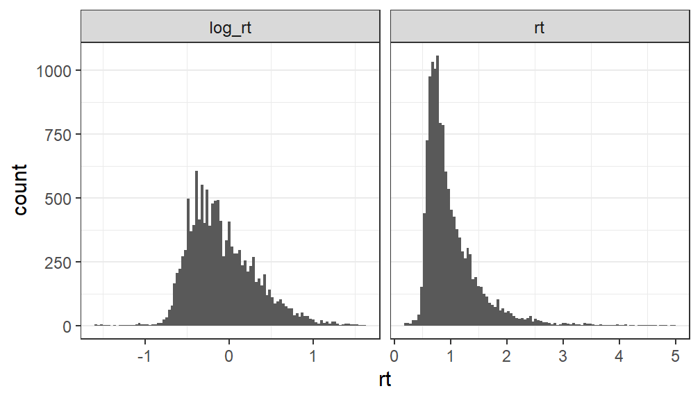

```r
fhch_long <- fhch %>%
  pivot_longer(cols = c(rt, log_rt), names_to = "rt_type", values_to = "rt")
ggplot(fhch_long, aes(rt)) +
  geom_histogram(bins = 100) +
  facet_wrap(vars(rt_type), scales = "free_x")
```

## Descriptive Analysis

The main factors in the experiment were the between-subjects factor `task` (`naming` vs. `lexdec`), and the within-subjects factors `stimulus` (`word` vs. `nonword`), `density` (`low` vs. `high`), and `frequency` (`low` vs. `high`). Before running an analysis it is a good idea to visually inspect the data to gather some expectations regarding the results. Should the statistical results dramatically disagree with the expectations this suggests some type of error along the way (e.g., model misspecification) or at least encourages a thorough check to make sure everything is correct. We first begin by plotting the data aggregated by-participant.

In each plot we plot the raw data in the background. To make the individual data points visible we use `ggbeeswarm::geom_quasirandom` and `alpha = 0.5` for semi-transparency. On top of this we add a (transparent) box plot as well as the mean and standard error.

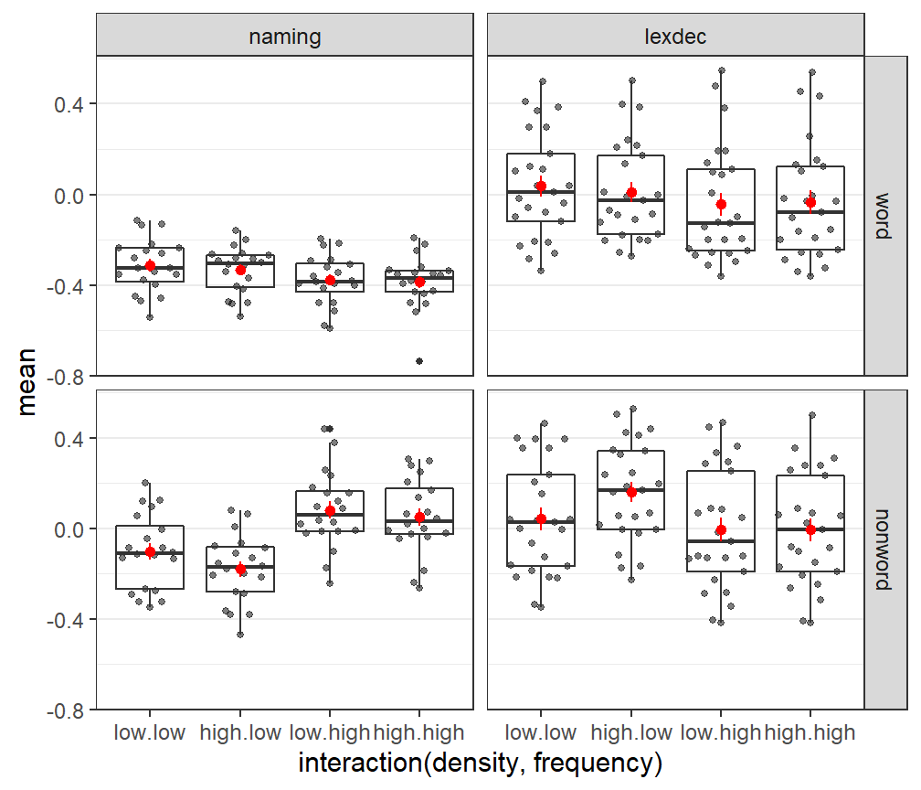

```r
agg_p <- fhch %>%
  group_by(id, task, stimulus, density, frequency) %>%
  summarise(mean = mean(log_rt)) %>%
  ungroup()

ggplot(agg_p, aes(x = interaction(density,frequency), y = mean)) +
  ggbeeswarm::geom_quasirandom(alpha = 0.5) +
  geom_boxplot(fill = "transparent") +
  stat_summary(colour = "red") +
  facet_grid(cols = vars(task), rows = vars(stimulus))
```

Now we plot the same data but aggregated across items:

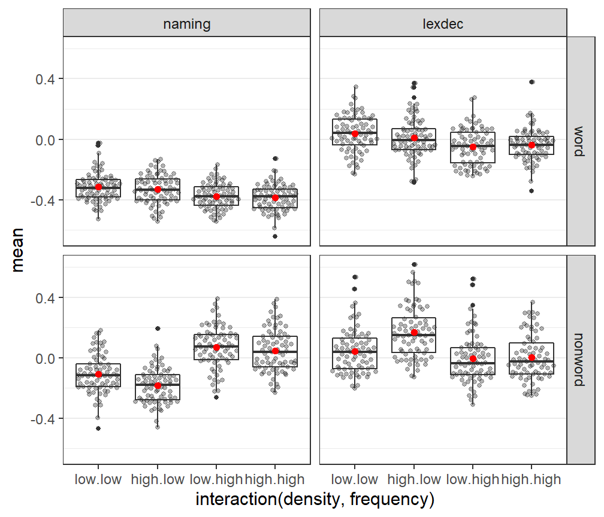

```r
agg_i <- fhch %>% group_by(item, task, stimulus, density, frequency) %>%
  summarise(mean = mean(log_rt)) %>%
  ungroup()

ggplot(agg_i, aes(x = interaction(density,frequency), y = mean)) +
  ggbeeswarm::geom_quasirandom(alpha = 0.3) +
  geom_boxplot(fill = "transparent") +
  stat_summary(colour = "red") +
  facet_grid(cols = vars(task), rows = vars(stimulus))
```

## Model Setup

To set up a mixed model it is important to identify which factors vary within which grouping factor generating random variability (i.e., grouping factors are sources of stochastic variability). The two grouping factors are participants (`id`) and items (`item`). The within-participant factors are `stimulus`, `density`, and `frequency`. The within-item factor is `task`. The ‘maximal model’ (Barr, Levy, Scheepers, and Tily, 2013) therefore is the model with by-participant random slopes for `stimulus`, `density`, and `frequency` and their interactions and by-item random slopes for `task`.

It is rather common that a maximal model with a complicated random effect structure, such as the present one, does not converge successfully. The best indicator of this is a “singular fit” warning. A model with a singular fit warning should not be reported or used. Instead, one should make sure that qualitatively the same results are also observed with a model without singular fit warnings. If the maximal model that does not converge and a reduced model without a singular fit warning (i.e., the final model) diverge in their results, results should only be interpreted cautiously.

In case of a singular fit or another indicator of a convergence problem, the usual first step is removing the correlations among the random terms. In our example, there are two sets of correlations, one for each random effect grouping variable. Consequently, we can build four model that have the maximal structure in terms of random-slopes and only differ in which correlations among random terms are calculated:

1. With all correlations.
2. No correlation among by-item random effects (i.e., no correlation between random intercept and `task` random slope).
3. No correlation among by-participant random effect terms (i.e., no correlation among random slopes themselves and between the random slopes and the random intercept).
4. No correlation among either random grouping factor.

The next decision to be made is which method to use for obtaining $p$-values. The default method is `KR` (=Kenward-Roger) which provides the best control against anti-conservative results. However, `KR` needs quite a lot of RAM, especially with complicated random effect structures and large data sets. As in this case we have both, relatively large data (i.e., many levels on each random effect, especially the item random effect) and a complicated random effect structure, it seems a reasonable decision to choose another method. The second ‘best’ method (in terms of controlling for Type I errors) is the ‘Satterthwaite’ approximation, `method='S'`. It provides a similar control of Type I errors as the Kenward-Roger approximation and needs less RAM, however one downside is that it simply fails in some cases.

## Finding the Final Model

The following code fits the four models using the Satterthwaite method. To suppress random effects we use the `||` notation. Note that it is necessary to set `expand_re=TRUE` when suppressing random effects among variables that are entered as factors and not as numerical variables (all independent variables in the present case are factors). Also note that `mixed` automatically uses appropriate contrast coding if factors are included in interactions (`contr.sum`) in contrast to the `R` default (which is `contr.treatment`). To make sure the estimation does not end prematurely we set the allowed number of function evaluations to a very high value (using `lmerControl`).

However, because fitting the models in R might take quite a while, you should also be able to load the fitted binary files them from [this url](https://raw.githubusercontent.com/singmann/afex/master/development/freeman_models.rda) and then load them in R with `load("freeman_models.rda")`.

```r
m1s <- mixed(log_rt ~ task*stimulus*density*frequency +
               (stimulus*density*frequency|id)+
               (task|item), fhch, method = "S",
             control = lmerControl(optCtrl = list(maxfun = 1e6)))
```

```
## boundary (singular) fit: see ?isSingular
```

```r
m2s <- mixed(log_rt ~ task*stimulus*density*frequency +
               (stimulus*density*frequency|id)+
               (task||item), fhch, method = "S",
             control = lmerControl(optCtrl = list(maxfun = 1e6)), expand_re = TRUE)
```

```
## boundary (singular) fit: see ?isSingular
```

```r
m3s <- mixed(log_rt ~ task*stimulus*density*frequency +
               (stimulus*density*frequency||id)+
               (task|item), fhch, method = "S",
             control = lmerControl(optCtrl = list(maxfun = 1e6)), expand_re = TRUE)
```

```
## boundary (singular) fit: see ?isSingular
```

```r
m4s <- mixed(log_rt ~ task*stimulus*density*frequency +
               (stimulus*density*frequency||id)+
               (task||item), fhch, method = "S",
             control = lmerControl(optCtrl = list(maxfun = 1e6)), expand_re = TRUE)
```

```
## boundary (singular) fit: see ?isSingular
```

We can see that fitting each of these models emits the “singular fit” message (it is technically a `message` and not a `warning`) indicating that the model is over-parameterized and did not converge successfully. In particular, this message indicates that the model is specified with more random effect parameters than can be estimated given the current data.

It is instructive to see that even with a comparatively large number of observations, 12960, a set of seven random slopes for the by-participant term and one random slope for the by-item term cannot be estimated successfully. And this holds even after removing all correlations. Thus, it should not be surprising that similar sized models regularly do not converge with smaller numbers of observations. Furthermore, we are here in the fortunate situation that each factor has only two levels. A factor with more levels corresponds to more parameters of the random effect terms.

Before deciding what to do next, we take a look at the estimated random effect estimates. We do so for the model without any correlations. Note that for `afex` models we usually do not want to use the `summary` method as it prints the results on the level of the model coefficients and not model terms. But for the random effects we have to do so. However, we are only interested in the random effect terms so we only print those using `summary(model)$varcor`.

```r
summary(m4s)$varcor
```

```
##  Groups   Name                                    Std.Dev.
##  item     re2.task1                               0.0568715
##  item.1   (Intercept)                             0.0537587
##  id       re1.stimulus1_by_density1_by_frequency1 0.0077923
##  id.1     re1.density1_by_frequency1              0.0000000
##  id.2     re1.stimulus1_by_frequency1             0.0000000
##  id.3     re1.stimulus1_by_density1               0.0000000
##  id.4     re1.frequency1                          0.0179993
##  id.5     re1.density1                            0.0000000
##  id.6     re1.stimulus1                           0.0445333
##  id.7     (Intercept)                             0.1936292
##  Residual                                         0.3001905
```

The output shows that the estimated SDs of the random slopes of the two-way interactions are all zero. However, because we cannot remove the random slopes for the two way interaction while retaining the three-way interaction, we start by removing the three-way interaction first.

```r
m5s <- mixed(log_rt ~ task*stimulus*density*frequency +
               ((stimulus+density+frequency)^2||id)+
               (task||item), fhch, method = "S",
             control = lmerControl(optCtrl = list(maxfun = 1e6)), expand_re = TRUE)
```

```
## boundary (singular) fit: see ?isSingular
```

```r
summary(m5s)$varcor
```

```
##  Groups   Name                        Std.Dev.
##  item     re2.task1                   5.6826e-02
##  item.1   (Intercept)                 5.3736e-02
##  id       re1.density1_by_frequency1  0.0000e+00
##  id.1     re1.stimulus1_by_frequency1 0.0000e+00
##  id.2     re1.stimulus1_by_density1   0.0000e+00
##  id.3     re1.frequency1              1.7966e-02
##  id.4     re1.density1                1.4422e-05
##  id.5     re1.stimulus1               4.4539e-02
##  id.6     (Intercept)                 1.9374e-01
##  Residual                             3.0030e-01
```

Not too surprisingly, this model also produces a singular fit. Inspection of the estimates shows that the two-way interaction of the slopes are still estimated to be zero. So we remove those in the next step.

```r
m6s <- mixed(log_rt ~ task*stimulus*density*frequency +
               (stimulus+density+frequency||id)+
               (task||item), fhch, method = "S",
             control = lmerControl(optCtrl = list(maxfun = 1e6)),
             expand_re = TRUE)
```

```
## boundary (singular) fit: see ?isSingular
```

This model still shows a singular fit warning. The random effect estimates below show a potential culprit.

```r
summary(m6s)$varcor
```

```
##  Groups   Name           Std.Dev.
##  item     re2.task1      0.056831
##  item.1   (Intercept)    0.053737
##  id       re1.frequency1 0.017972
##  id.1     re1.density1   0.000000
##  id.2     re1.stimulus1  0.044524
##  id.3     (Intercept)    0.193659
##  Residual                0.300297
```

As in `m4s` above, the random effect SD for the density term is estimated to be zero. Thus, we remove this as well in the next step.

```r
m7s <- mixed(log_rt ~ task*stimulus*density*frequency +
               (stimulus+frequency||id)+
               (task||item), fhch, method = "S",
             control = lmerControl(optCtrl = list(maxfun = 1e6)), expand_re = TRUE)
```

This model finally does not emit a singular fit warning. Is this our final model? Before deciding on this, we see whether we can add the correlation terms again without running into any problems. We begin by adding the correlation to the by-participant term.

```r
m8s <- mixed(log_rt ~ task*stimulus*density*frequency +
               (stimulus+frequency|id)+
               (task||item), fhch, method = "S",
             control = lmerControl(optCtrl = list(maxfun = 1e6)), expand_re = TRUE)
```

```
## Warning: Model failed to converge with max|grad| = 0.00347544 (tol = 0.002, component 1)
```

This model does not show a singular fit message but emits another warning. Specifically, a warning that the absolute maximal gradient at the final solution is too high. This warning is not necessarily critical (i.e., it can be a false positive), but can also indicate serious problems. Consequently, we try adding the correlation between the by-item random terms instead:

```r
m9s <- mixed(log_rt ~ task*stimulus*density*frequency +
               (stimulus+frequency||id)+
               (task|item), fhch, method = "S",
             control = lmerControl(optCtrl = list(maxfun = 1e6)), expand_re = TRUE)
```

This model also does not show any warnings. Thus, we have arrived at the end of the model selection process.

## Results of Maximal and Final Model

We now have the following two relevant models.

- `m1s`: The maximal random effect structure justified by the design (i.e., the maximal model)
- `m9s`: The final model

Robust results are those that hold regardless across maximal and final (i.e., reduced) model. Therefore, let us compare the pattern of significant and non-significant effects.

```r
left_join(nice(m1s), nice(m9s), by = "Effect",
          suffix = c("_full", "_final"))
```

```
## Mixed Model Anova Table (Type 3 tests, S-method)
##
## Model: log_rt ~ task * stimulus * density * frequency + (stimulus *
## Model:     density * frequency | id) + (task | item)
## Data: fhch
##                             Effect   df_full     F_full p.value_full  df_final    F_final p.value_final
## 1                             task  1, 43.58  13.71 ***        <.001  1, 43.51  13.68 ***         <.001
## 2                         stimulus  1, 50.50 151.03 ***        <.001  1, 50.57 151.38 ***         <.001
## 3                          density 1, 175.53       0.33         .569 1, 584.58       0.36          .547
## 4                        frequency  1, 71.17       0.55         .459  1, 70.27       0.56          .456
## 5                    task:stimulus  1, 51.45  70.91 ***        <.001  1, 51.50  71.32 ***         <.001
## 6                     task:density 1, 184.47  16.22 ***        <.001 1, 578.72  17.89 ***         <.001
## 7                 stimulus:density 1, 247.85       1.13         .289 1, 584.60       1.19          .275
## 8                   task:frequency  1, 75.03  81.10 ***        <.001  1, 74.09  82.77 ***         <.001
## 9               stimulus:frequency 1, 165.95  55.85 ***        <.001 1, 584.78  63.29 ***         <.001
## 10               density:frequency 1, 215.83       0.11         .739 1, 584.62       0.11          .742
## 11           task:stimulus:density 1, 259.93  14.52 ***        <.001 1, 578.74  14.87 ***         <.001
## 12         task:stimulus:frequency 1, 178.33 110.95 ***        <.001 1, 578.91 124.16 ***         <.001
## 13          task:density:frequency 1, 228.12     5.53 *         .020 1, 578.75     5.93 *          .015
## 14      stimulus:density:frequency 1, 101.11     3.98 *         .049 1, 584.64     4.62 *          .032
## 15 task:stimulus:density:frequency 1, 108.10   10.19 **         .002 1, 578.77  11.72 ***         <.001
## ---
## Signif. codes:  0 ‘***’ 0.001 ‘**’ 0.01 ‘*’ 0.05 ‘+’ 0.1 ‘ ’ 1
```

What this shows is that the pattern of significant and non-significant effect is the same for both models. The only significant effect for which the evidence is not that strong is the 3-way interaction between `stimulus:density:frequency`. It is only just below .05 for the full model and has a somewhat lower value for the final model.

We can also see that one of the most noticeable differences between the maximal and the final model is the number of denominator degrees of freedom. This is highly influenced by the random effect structure and thus considerable larger in the final (i.e., reduced) model. The difference in the other statistics is lower.

## LRT Results

It is instructive to compare those results with results obtained using the comparatively ‘worst’ method for obtaining $p$-values implemented in `afex::mixed`, likelihood ratio tests. Likelihood ratio-tests should in principle deliver reasonable results for large data sets. A common rule of thumb is that the number of levels for each random effect grouping factor needs to be large, say above 50. Here, we have a very large number of items (600), but not that many participants (45). Thus, qualitative results should be the very similar, but it still is interesting to see exactly what happens. We therefore fit the final model using `method='LRT'`.

```r
m9lrt <- mixed(log_rt ~ task*stimulus*density*frequency +
               (stimulus+frequency||id)+
               (task|item), fhch, method = "LRT",
             control = lmerControl(optCtrl = list(maxfun = 1e6)),
             expand_re = TRUE)
m9lrt
```

```
## Mixed Model Anova Table (Type 3 tests, LRT-method)
##
## Model: log_rt ~ task * stimulus * density * frequency + (stimulus +
## Model:     frequency || id) + (task | item)
## Data: fhch
## Df full model: 23
##                             Effect df      Chisq p.value
## 1                             task  1  12.44 ***   <.001
## 2                         stimulus  1  70.04 ***   <.001
## 3                          density  1       0.37    .545
## 4                        frequency  1       0.57    .449
## 5                    task:stimulus  1  45.52 ***   <.001
## 6                     task:density  1  17.81 ***   <.001
## 7                 stimulus:density  1       1.21    .272
## 8                   task:frequency  1  53.81 ***   <.001
## 9               stimulus:frequency  1  60.64 ***   <.001
## 10               density:frequency  1       0.11    .741
## 11           task:stimulus:density  1  14.85 ***   <.001
## 12         task:stimulus:frequency  1 114.21 ***   <.001
## 13          task:density:frequency  1     5.96 *    .015
## 14      stimulus:density:frequency  1     4.65 *    .031
## 15 task:stimulus:density:frequency  1  11.71 ***   <.001
## ---
## Signif. codes:  0 ‘***’ 0.001 ‘**’ 0.01 ‘*’ 0.05 ‘+’ 0.1 ‘ ’ 1
```

The results in this case match the results of the Satterthwaite method. With lower numbers of levels of the grouping factor (e.g., less participants) this would not necessarily be expected.

## Summary of Results

Fortunately, the results from all models converged on the same pattern of significant and non-significant effects providing a high degree of confidence in the results. This might not be too surprising given the comparatively large number of total data points and the fact that each random effect grouping factor has a considerable number of levels (above 30 for both participants and items). In the following we focus on the final model using the Satterthwaite method, `m9s`.

In terms of the significant findings, there are many that seem to be in line with the descriptive results described above. For example, the highly significant effect of `task:stimulus:frequency` with $F(1, 578.91) = 124.16$, $p < .001$, appears to be in line with the observation that the frequency effect appears to change its sign depending on the `task:stimulus` cell (with `nonword` and `naming` showing the opposite patterns than the other three conditions). Consequently, we start by investigating this interaction further below.

## Follow-Up Analyses

Before investigating the significant interaction in detail it is a good idea to remind oneself what a significant interaction represents on a conceptual level; that one or multiple of the variables in the interaction moderate (i.e., affect) the effect of the other variable or variables. Consequently, there are several ways to investigate a significant interaction. Each of the involved variables can be seen as the moderating variables and each of the variables can be seen as the effect of interest. Which one of those possible interpretations is of interest in a given situation highly depends on the actual data and research question and multiple views can be ‘correct’ in a given situation.

In addition to this conceptual issue, there are also multiple technical ways to investigate a significant interaction. One approach not followed here is to split the data into subsets according to the moderating variables and compute the statistical model again for the subsets with the effect variable(s) as remaining fixed effect. This approach, also called *simple effects* analysis, is, for example, recommended by Maxwell and Delaney (2004) as it does not assume variance homogeneity and is faithful to the data at each level. The approach taken here is to simply perform the test on the estimated final model. This approach assumes variance homogeneity (i.e., that the variances in all groups are homogeneous) and has the added benefit that it is computationally relatively simple. In addition, it can all be achieved using the framework provided by [`emmeans`](https://cran.r-project.org/package=emmeans) (Lenth, 2017).

### task:stimulus:frequency Interaction

Our interest in the beginning is on the effect of `frequency` by `task:stimulus` combination. So let us first look at the estimated marginal means of this effect. In `emmeans` parlance these estimated means are called ‘least-square means’ because of historical reasons, but because of the lack of least-square estimation in mixed models we prefer the term estimated marginal means, or EMMs for short. Those can be obtained in the following way. To prevent `emmeans` from calculating the *df* for the EMMs (which can be quite costly), we use asymptotic *df*s (i.e., $z$ values and tests). `emmeans` requires to first specify the variable(s) one wants to treat as the effect variable(s) (here `frequency`) and then allows to specify condition variables.

```r
emm_options(lmer.df = "asymptotic") # also possible: 'satterthwaite', 'kenward-roger'
emm_i1 <- emmeans(m9s, "frequency", by = c("stimulus", "task"))
emm_i1
```

```
## NOTE: Results may be misleading due to involvement in interactions
```

```
## stimulus = word, task = naming:
##  frequency   emmean     SE  df asymp.LCL asymp.UCL
##  low       -0.32333 0.0455 Inf   -0.4125   -0.2342
##  high      -0.38210 0.0455 Inf   -0.4713   -0.2929
##
## stimulus = nonword, task = naming:
##  frequency   emmean     SE  df asymp.LCL asymp.UCL
##  low       -0.14294 0.0455 Inf   -0.2321   -0.0538
##  high       0.06405 0.0455 Inf   -0.0252    0.1533
##
## stimulus = word, task = lexdec:
##  frequency   emmean     SE  df asymp.LCL asymp.UCL
##  low        0.02337 0.0413 Inf   -0.0576    0.1044
##  high      -0.04017 0.0413 Inf   -0.1211    0.0408
##
## stimulus = nonword, task = lexdec:
##  frequency   emmean     SE  df asymp.LCL asymp.UCL
##  low        0.10455 0.0413 Inf    0.0235    0.1856
##  high      -0.00632 0.0413 Inf   -0.0873    0.0746
##
## Results are averaged over the levels of: density
## Degrees-of-freedom method: asymptotic
## Confidence level used: 0.95
```

The returned values are in line with our observation that the `nonword` and `naming` condition diverges from the other three. But is there actual evidence that the effect flips? We can test this using additional `emmeans` functionality. Specifically, we first use the `pairs` function which provides us with a pairwise test of the effect of `frequency` in each `task:stimulus` combination. Then we need to combine the four tests within one object to obtain a family-wise error rate correction which we do via `update(..., by = NULL)` (i.e., we revert the effect of the `by` statement from the earlier `emmeans` call) and finally we select the `holm` method for controlling for family wise error rate (the Holm method is uniformly more powerful than the Bonferroni).

```r
update(pairs(emm_i1), by = NULL, adjust = "holm")
```

```
## NOTE: Results may be misleading due to involvement in interactions
```

```
##  contrast   stimulus task   estimate     SE  df z.ratio p.value
##  low - high word     naming   0.0588 0.0149 Inf   3.941 0.0002
##  low - high nonword  naming  -0.2070 0.0150 Inf -13.823 <.0001
##  low - high word     lexdec   0.0635 0.0167 Inf   3.807 0.0002
##  low - high nonword  lexdec   0.1109 0.0167 Inf   6.619 <.0001
##
## Results are averaged over the levels of: density
## Degrees-of-freedom method: asymptotic
## P value adjustment: holm method for 4 tests
```

We could also use a slightly more powerful method than the Holm method, method `free` from package `multcomp`. This method takes the correlation of the model parameters into account. However, results do not differ much here:

```r
summary(as.glht(update(pairs(emm_i1), by = NULL)), test = adjusted("free"))
```

```
##
##   Simultaneous Tests for General Linear Hypotheses
##
## Linear Hypotheses:
##                                  Estimate Std. Error z value Pr(>|z|)
## low - high, word, naming == 0     0.05877    0.01491   3.941 0.000162 ***
## low - high, nonword, naming == 0 -0.20699    0.01497 -13.823  < 2e-16 ***
## low - high, word, lexdec == 0     0.06353    0.01669   3.807 0.000162 ***
## low - high, nonword, lexdec == 0  0.11086    0.01675   6.619 1.11e-10 ***
## ---
## Signif. codes:  0 ‘***’ 0.001 ‘**’ 0.01 ‘*’ 0.05 ‘.’ 0.1 ‘ ’ 1
## (Adjusted p values reported -- free method)
```

We see that the results are exactly as expected. In the `nonword` and `naming` condition we have a clear negative effect of frequency while in the other three conditions it is clearly positive.

We could now also use `emmeans` and re-transform the estimates back onto the original RT response scale. For this, we can again `update` the `emmeans` object by using `tran = "log"` to specify the transformation and then indicating we want the means on the response scale with `type = "response"`. These values might be used for plotting.

```r
emm_i1b <- update(emm_i1, tran = "log", type = "response", by = NULL)
emm_i1b
```

```
##  frequency stimulus task   response     SE  df asymp.LCL asymp.UCL
##  low       word     naming    0.724 0.0329 Inf     0.662     0.791
##  high      word     naming    0.682 0.0310 Inf     0.624     0.746
##  low       nonword  naming    0.867 0.0394 Inf     0.793     0.948
##  high      nonword  naming    1.066 0.0485 Inf     0.975     1.166
##  low       word     lexdec    1.024 0.0423 Inf     0.944     1.110
##  high      word     lexdec    0.961 0.0397 Inf     0.886     1.042
##  low       nonword  lexdec    1.110 0.0459 Inf     1.024     1.204
##  high      nonword  lexdec    0.994 0.0410 Inf     0.916     1.077
##
## Results are averaged over the levels of: density
## Degrees-of-freedom method: asymptotic
## Confidence level used: 0.95
## Intervals are back-transformed from the log scale
```

A more direct approach for plotting the interaction is via `afex_plot`. For a plot that is not too busy it makes sense to specify across which grouping factor the individual level data should be aggregated. We use the participant variable `"id"` here. We also use `ggbeeswarm::geom_quasirandom` as the geom for the data in the background following the example in the `afex_plot` vignette.

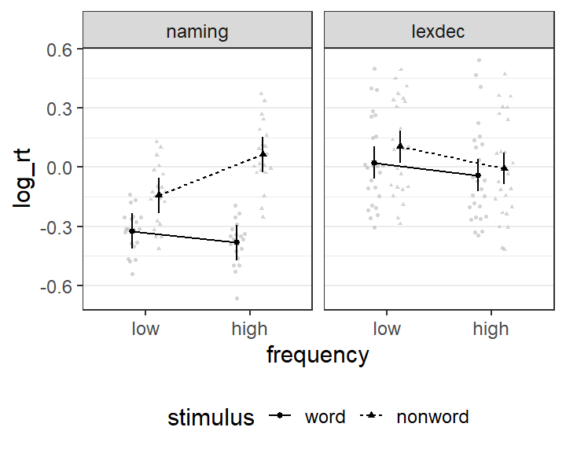

```r
afex_plot(m9s, "frequency", "stimulus", "task", id = "id",
          data_geom = ggbeeswarm::geom_quasirandom,
          data_arg = list(
            dodge.width = 0.5,  ## needs to be same as dodge
            cex = 0.8,
            color = "darkgrey"))
```

### task:stimulus:density:frequency Interaction

As the last example, let us take a look at the significant four-way interaction of `task:stimulus:density:frequency`, $F(1, 578.77) = 11.72$, $p < .001$. Here we might be interested in a slightly more difficult question namely whether the `density:frequency` interaction varies across `task:stimulus` conditions. If we again look at the figures above, it appears that there is a difference between `low:low` and `high:low` in the `nonword` and `lexdec` condition, but not in the other conditions.

Looking at the 2-way interaction of `density:frequency` by the `task:stimulus` interaction can be done using `emmeans` using the `joint_test` function. We simply need to specify the appropriate `by` variables and get conditional tests this way.

```r
joint_tests(m9s, by = c("stimulus", "task"))
```

```
## stimulus = word, task = naming:
##  model term        df1 df2 F.ratio p.value
##  density             1 Inf   1.292 0.2556
##  frequency           1 Inf  15.530 0.0001
##  density:frequency   1 Inf   0.196 0.6578
##
## stimulus = nonword, task = naming:
##  model term        df1 df2 F.ratio p.value
##  density             1 Inf  17.926 <.0001
##  frequency           1 Inf 191.069 <.0001
##  density:frequency   1 Inf   3.656 0.0559
##
## stimulus = word, task = lexdec:
##  model term        df1 df2 F.ratio p.value
##  density             1 Inf   0.359 0.5491
##  frequency           1 Inf  14.494 0.0001
##  density:frequency   1 Inf   1.669 0.1964
##
## stimulus = nonword, task = lexdec:
##  model term        df1 df2 F.ratio p.value
##  density             1 Inf  15.837 0.0001
##  frequency           1 Inf  43.811 <.0001
##  density:frequency   1 Inf  14.806 0.0001
```

This test indeed shows that the `density:frequency` interaction is only significant in the `nonword` and `lexdec` condition. Next, let’s see if we can unpack this interaction in a meaningful manner. For this we compare `low:low` and `high:low` in each of the four groups. And just for the sake of making the example more complex, we also compare `low:high` and `high:high`.

To do so, we first need to setup a new set of EMMs. Specifically, we get the EMMs of the two variables of interest, density and frequency, using the same `by` specification as the `joint_test` call. We can then setup custom contrasts that tests our hypotheses.

```r
emm_i2 <- emmeans(m2s, c("density", "frequency"), by = c("stimulus", "task"))
emm_i2
```

```
## stimulus = word, task = naming:
##  density frequency   emmean     SE  df asymp.LCL asymp.UCL
##  low     low       -0.31384 0.0448 Inf   -0.4016  -0.22613
##  high    low       -0.33268 0.0408 Inf   -0.4126  -0.25276
##  low     high      -0.37741 0.0466 Inf   -0.4687  -0.28611
##  high    high      -0.38644 0.0472 Inf   -0.4789  -0.29399
##
## stimulus = nonword, task = naming:
##  density frequency   emmean     SE  df asymp.LCL asymp.UCL
##  low     low       -0.10399 0.0499 Inf   -0.2019  -0.00611
##  high    low       -0.18230 0.0441 Inf   -0.2688  -0.09580
##  low     high       0.07823 0.0519 Inf   -0.0236   0.18004
##  high    high       0.04902 0.0494 Inf   -0.0478   0.14588
##
## stimulus = word, task = lexdec:
##  density frequency   emmean     SE  df asymp.LCL asymp.UCL
##  low     low        0.03713 0.0403 Inf   -0.0419   0.11617
##  high    low        0.00933 0.0368 Inf   -0.0627   0.08138
##  low     high      -0.04512 0.0419 Inf   -0.1272   0.03696
##  high    high      -0.03479 0.0424 Inf   -0.1179   0.04828
##
## stimulus = nonword, task = lexdec:
##  density frequency   emmean     SE  df asymp.LCL asymp.UCL
##  low     low        0.04480 0.0449 Inf   -0.0432   0.13278
##  high    low        0.16331 0.0398 Inf    0.0852   0.24140
##  low     high      -0.00729 0.0466 Inf   -0.0987   0.08411
##  high    high      -0.00564 0.0444 Inf   -0.0927   0.08140
##
## Degrees-of-freedom method: asymptotic
## Confidence level used: 0.95
```

To control for the family wise error rate across all tests, we again use `update(..., by = NULL)` on the result to revert the effect of the conditioning.

```r
# desired contrats:
des_c <- list(
  ll_hl = c(1, -1, 0, 0),
  lh_hh = c(0, 0, 1, -1)
  )
update(contrast(emm_i2, des_c), by = NULL, adjust = "holm")
```

```
##  contrast stimulus task   estimate     SE  df z.ratio p.value
##  ll_hl    word     naming  0.01884 0.0210 Inf  0.895  1.0000
##  lh_hh    word     naming  0.00904 0.0212 Inf  0.426  1.0000
##  ll_hl    nonword  naming  0.07831 0.0222 Inf  3.525  0.0030
##  lh_hh    nonword  naming  0.02921 0.0210 Inf  1.391  0.9847
##  ll_hl    word     lexdec  0.02780 0.0200 Inf  1.391  0.9847
##  lh_hh    word     lexdec -0.01033 0.0199 Inf -0.520  1.0000
##  ll_hl    nonword  lexdec -0.11850 0.0211 Inf -5.628  <.0001
##  lh_hh    nonword  lexdec -0.00165 0.0197 Inf -0.084  1.0000
##
## Degrees-of-freedom method: asymptotic
## P value adjustment: holm method for 8 tests
```

In contrast to our expectation, the results show two significant effects and not only one. In line with our expectations, in the `nonword` and `lexdec` condition the EMM of `low:low` is smaller than the EMM for `high:low`, $z = -5.63$, $p < .0001$. However, in the `nonword` and `naming` condition we found the opposite pattern; the EMM of `low:low` is larger than the EMM for `high:low`, $z = 3.53$, $p = .003$. For all other effects $|z| < 1.4$, $p > .98$. In addition, there is no difference between `low:high` and `high:high` in any condition.

## References

- Barr, D. J., Levy, R., Scheepers, C., & Tily, H. J. (2013). Random effects structure for confirmatory hypothesis testing: Keep it maximal. *Journal of Memory and Language*, 68(3), 255-278. https://doi.org/10.1016/j.jml.2012.11.001
- Bretz, F., Hothorn, T., & Westfall, P. H. (2011). *Multiple comparisons using R*. Boca Raton, FL: CRC Press. https://CRAN.R-project.org/package=multcomp
- Freeman, E., Heathcote, A., Chalmers, K., & Hockley, W. (2010). Item effects in recognition memory for words. *Journal of Memory and Language*, 62(1), 1-18. https://doi.org/10.1016/j.jml.2009.09.004
- Lenth, R. (2017). *emmeans: Estimated Marginal Means, aka Least-Squares Means*. R package version 0.9.1. https://CRAN.R-project.org/package=emmeans
- Maxwell, S. E., & Delaney, H. D. (2004). *Designing experiments and analyzing data: a model-comparisons perspective*. Mahwah, N.J.: Lawrence Erlbaum Associates.